# Question

A continuous random variable (spinner/random number generator/infinite population) can be visualized with a density curve, a spinner, and a cumulative curve.

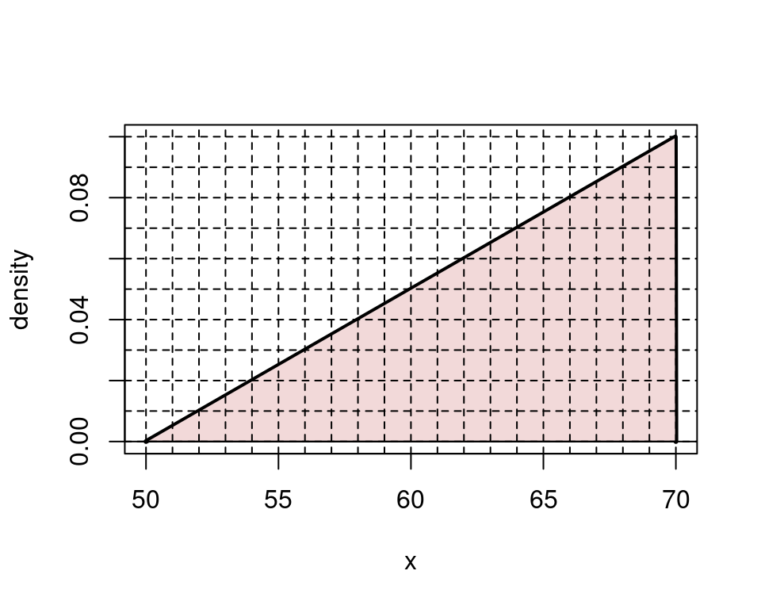

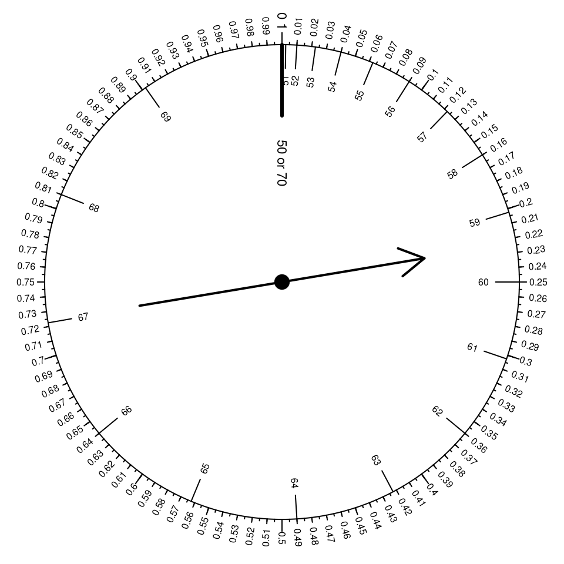

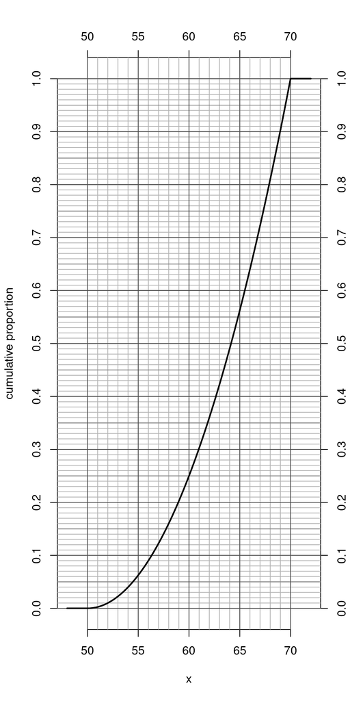

## Answerlist

- Evaluate $\text{prop}[\mathbf{x}<54]$
- Evaluate $\text{prop}[\mathbf{x}>66]$
- Evaluate $\text{prop}[|\mathbf{x}-61|<3]$
- Determine integer $b$ such that $\text{prop}[\mathbf{x}<b]=0.81$
- Determine integer $b$ such that $\text{prop}[\mathbf{x}>b]=0.99$
- Determine integer $r$ such that $\text{prop}[|\mathbf{x}-61|<r]=0.11$

# Solution

For each problem, you can use any of the visualizations. In short, the answers:

```
## 0.04 0.36 0.33 68 52 1
```

## Answerlist

- The answer is 0.04 because $\text{prop}[\mathbf{x}<54]=0.04$. The following visualizations show this. The density curve can be used by counting percent boxes. Each box adds 0.01 to the proportion. You may need to count half boxes, or find partial boxes that add to whole boxes.

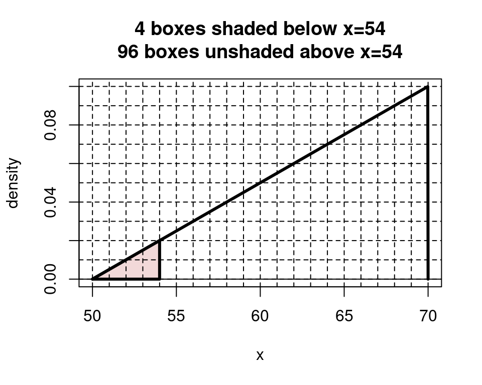

  On the spinner, you can determine the size of a region by using the outside tickmarks.

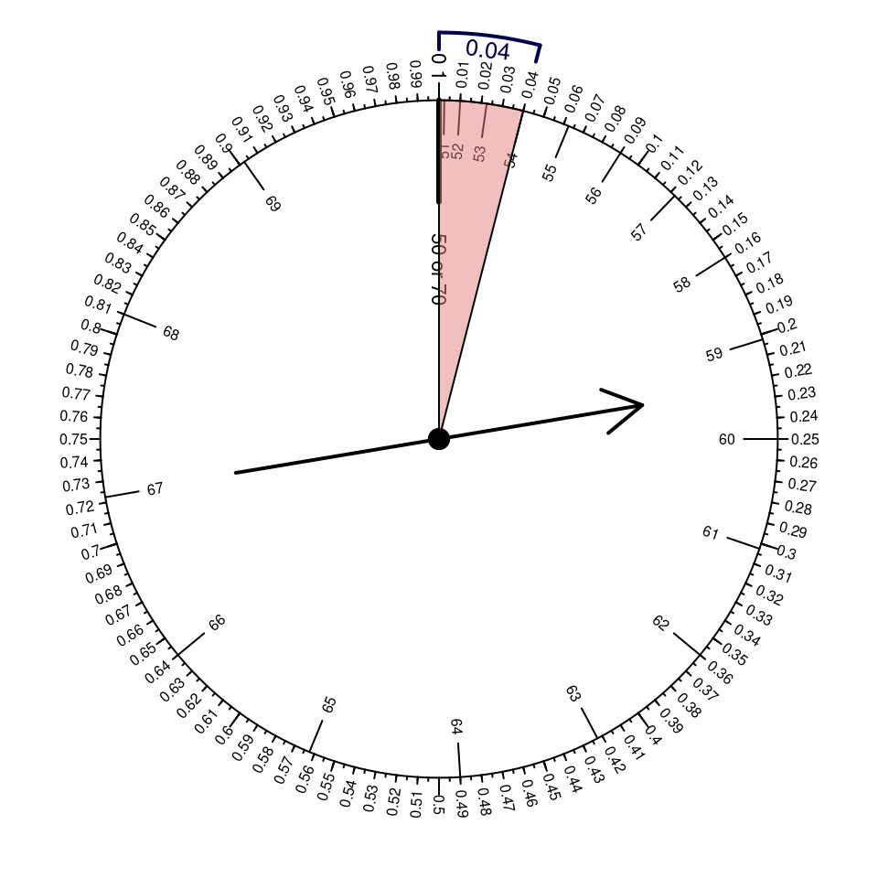

  You need to read coordinates to use the cumulative curve.

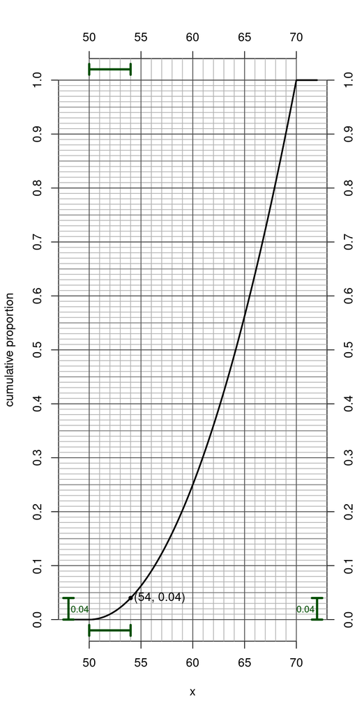

- The answer is 0.36 because $\text{prop}[\mathbf{x}>66]=0.36$. The following visualizations show this. The density curve can be used by counting percent boxes. Each box adds 0.01 to the proportion. You may need to count half boxes, or find partial boxes that add to whole boxes.

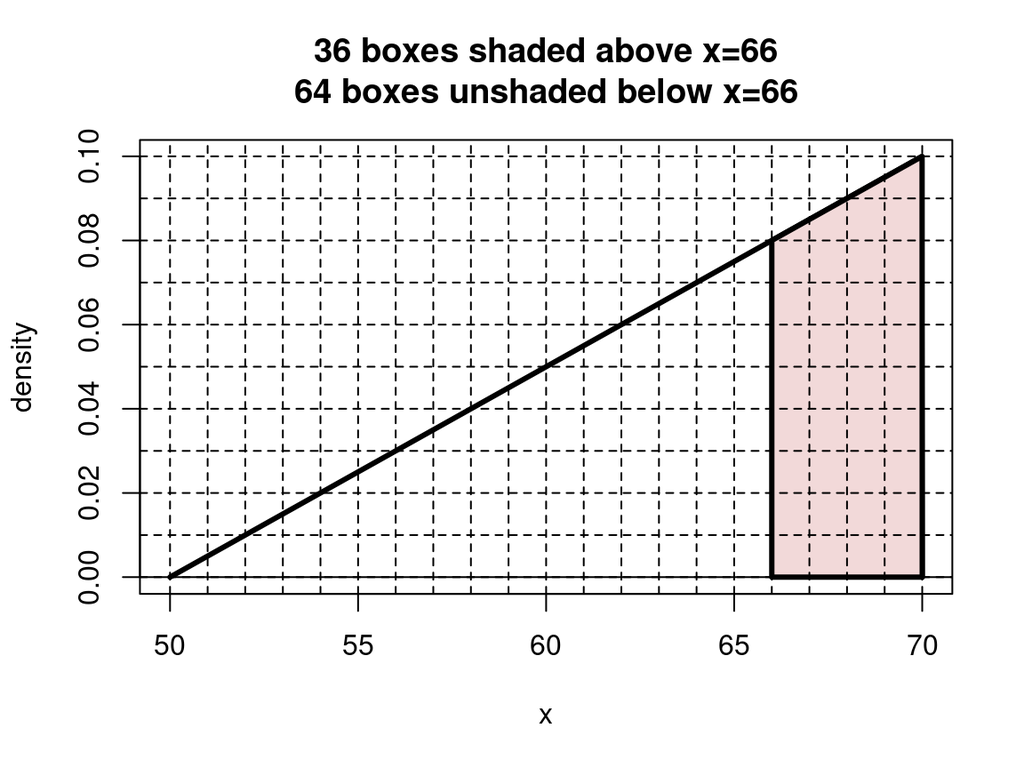

  On the spinner, you can determine the size of a region by using the outside tickmarks.
  $$1-0.64=0.36$$

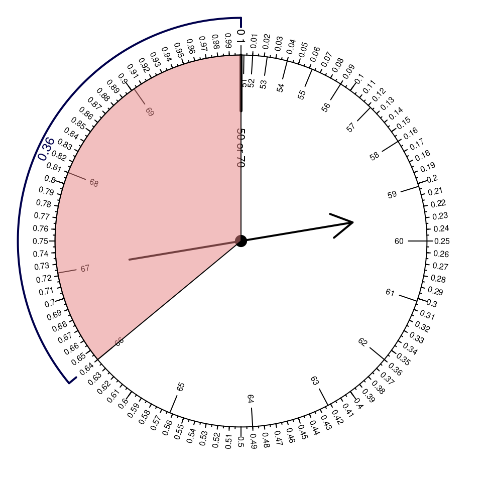

  You need to read coordinates to use the cumulative curve.
  $$1-0.64=0.36$$

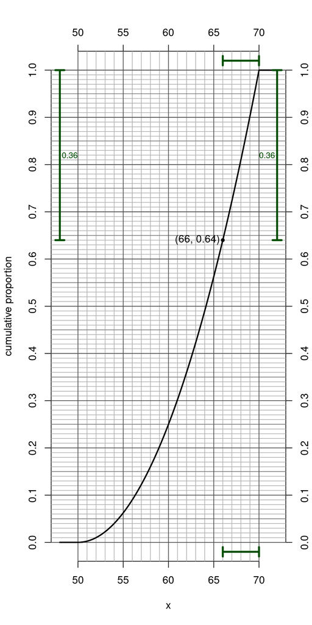

- The answer is 0.33 because $\text{prop}[|\mathbf{x}-61|<3]=0.33$. It helps to point out this interval has a center of 61 and a radius of 3, and thus a lower bound of 58 and an upper bound of 64. The following visualizations show this. The density curve can be used by counting percent boxes. Each box adds 0.01 to the proportion. You may need to count half boxes, or find partial boxes that add to whole boxes.

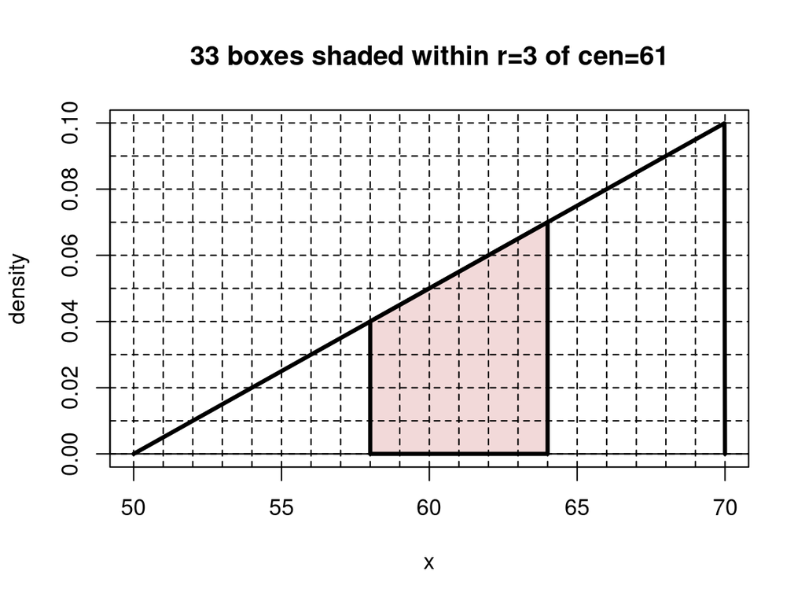

  On the spinner, you can determine the size of a region by using the outside tickmarks. The lower bound is at $x=58$, which corresponds to a cumulative proportion of 0.16. The upper bound is at $x=64$, which corresponds to a cumulative proportion of 0.49.
  $$0.49-0.16=0.33$$

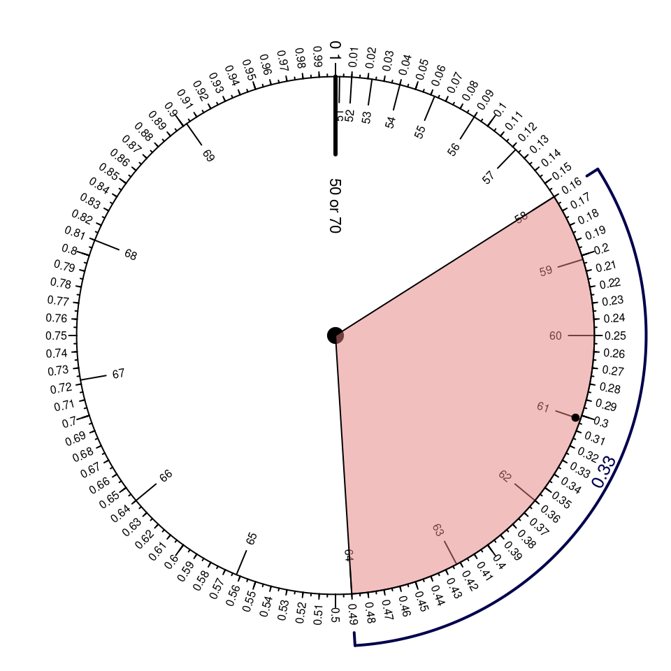

  You need to read coordinates to use the cumulative curve. The lower bound is at $x=58$, which corresponds to a cumulative proportion of 0.16. The upper bound is at $x=64$, which corresponds to a cumulative proportion of 0.49.
  $$0.49-0.16=0.33$$

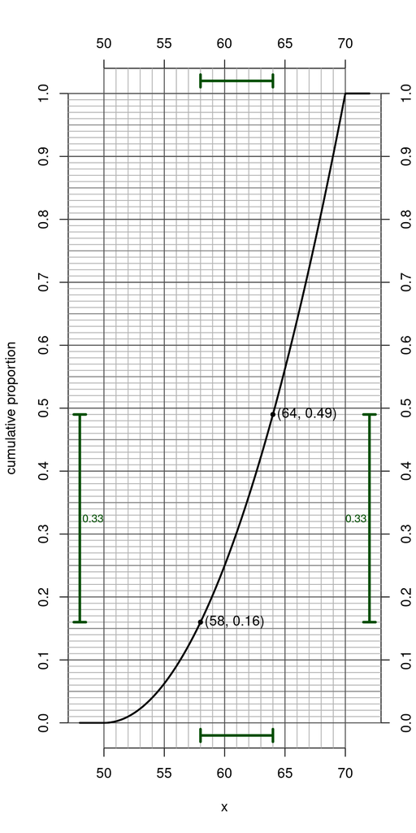

- The answer is 68 because $\text{prop}[\mathbf{x}<68]=0.81$. The following visualizations show this. The density curve can be used by counting percent boxes. Each box adds 0.01 to the proportion. You may need to count half boxes, or find partial boxes that add to whole boxes.

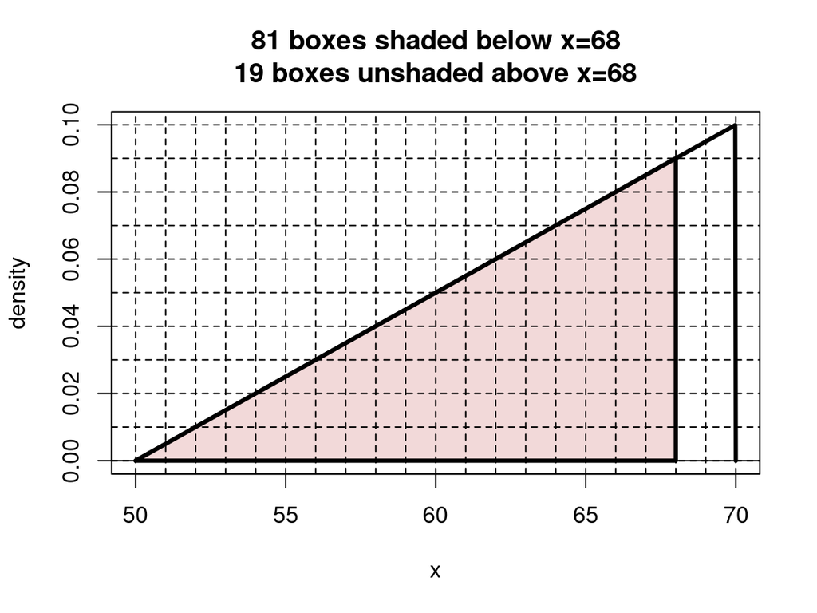

  On the spinner, you can determine the size of a region by using the outside tickmarks.

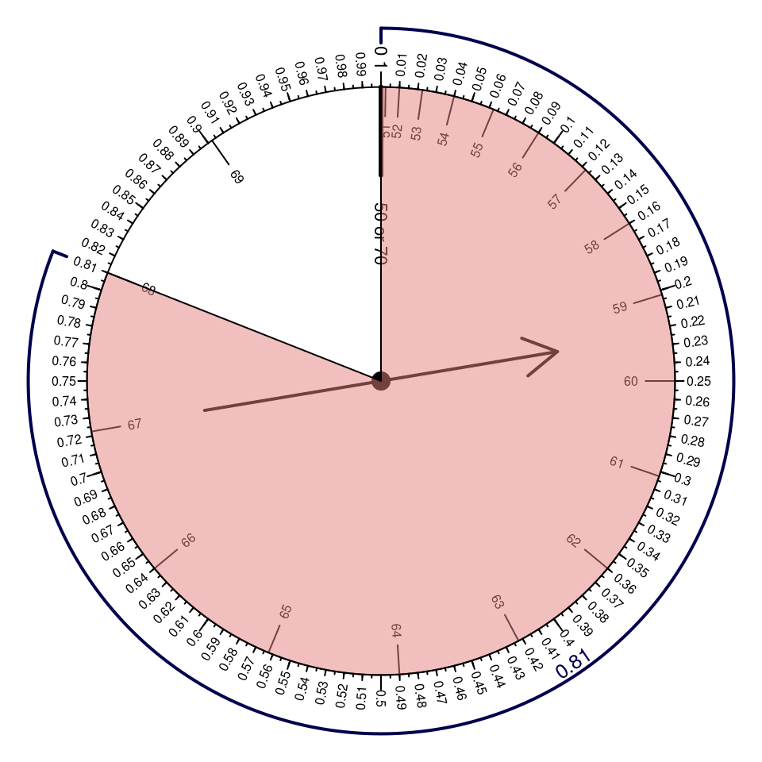

  You need to read coordinates to use the cumulative curve.

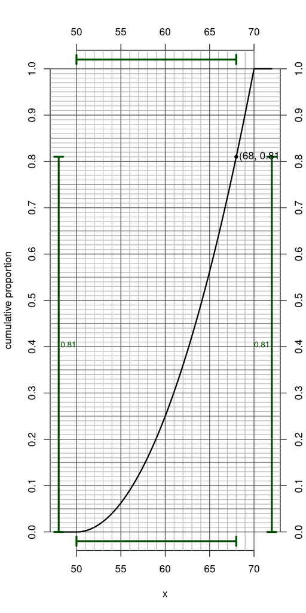

- The answer is 52 because $\text{prop}[\mathbf{x}>52]=0.99$. The following visualizations show this. The density curve can be used by counting percent boxes. Each box adds 0.01 to the proportion. You may need to count half boxes, or find partial boxes that add to whole boxes.

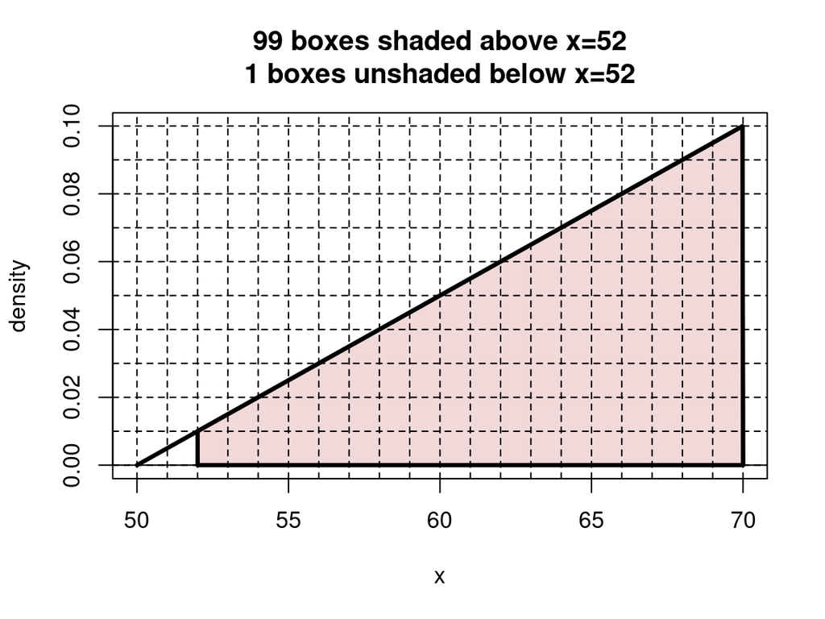

  On the spinner, you can determine the size of a region by using the outside tickmarks.
  $$1-0.01=0.99$$

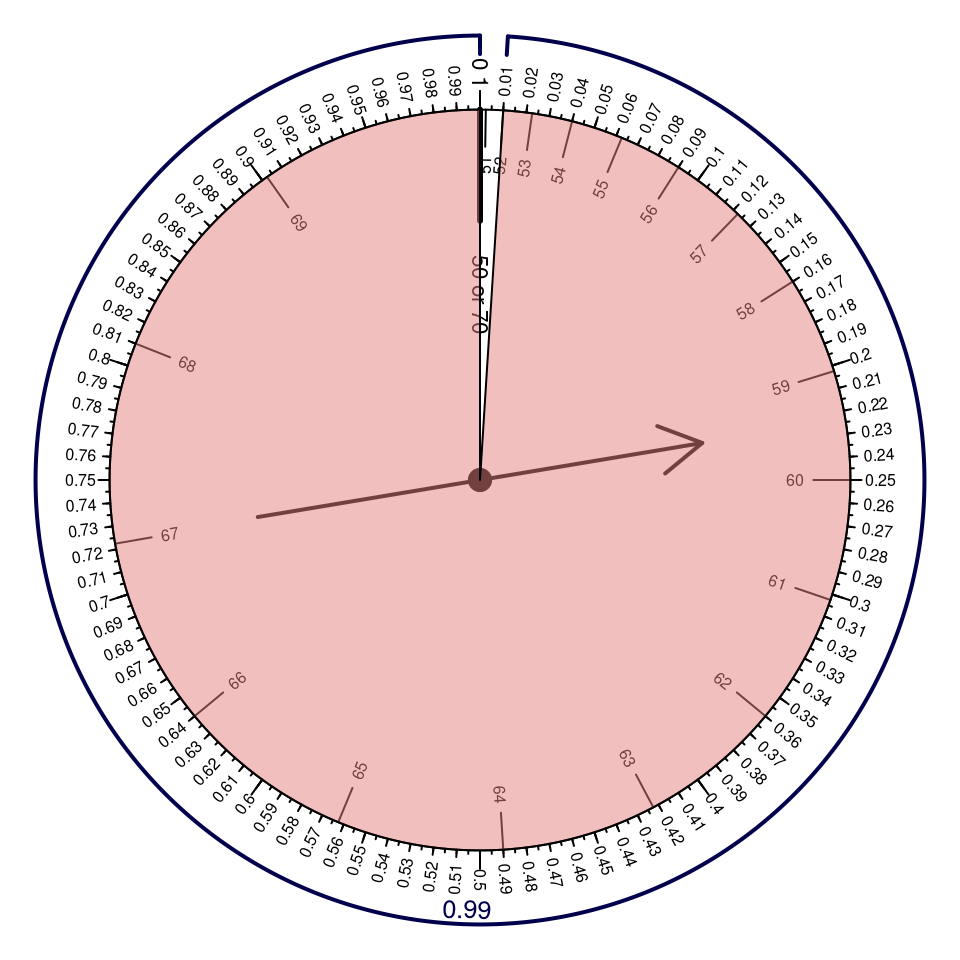

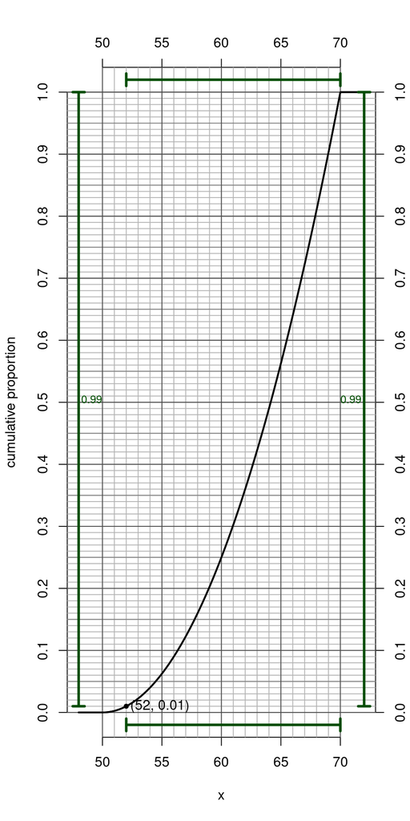

- The answer is 1 because $\text{prop}[|\mathbf{x}-61|<1]=0.11$. You will need to guess and check to arrive at this answer. The following shows how to check after making the correct guess. This interval has a center of 61 and a radius of 1, and thus a lower bound of 60 and an upper bound of 62. The density curve can be used by counting percent boxes. Each box adds 0.01 to the proportion. You may need to count half boxes, or find partial boxes that add to whole boxes.

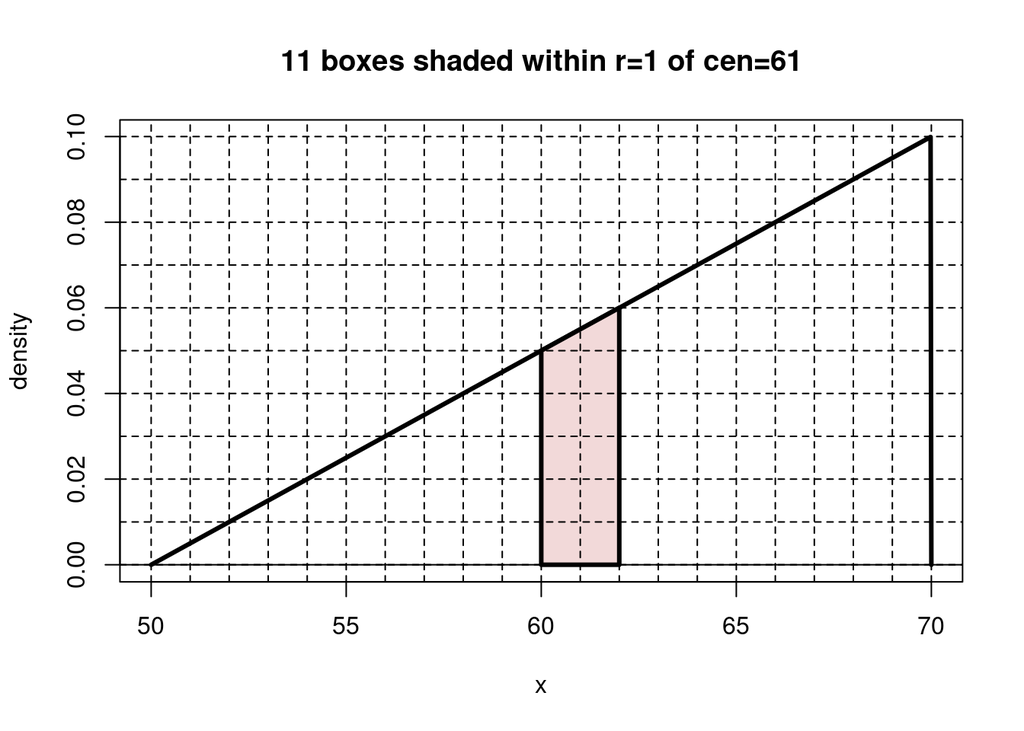

  On the spinner, you can determine the size of a region by using the outside tickmarks. The lower bound is at $x=60$, which corresponds to a cumulative proportion of 0.25. The upper bound is at $x=62$, which corresponds to a cumulative proportion of 0.36.
  $$0.36-0.25=0.11$$

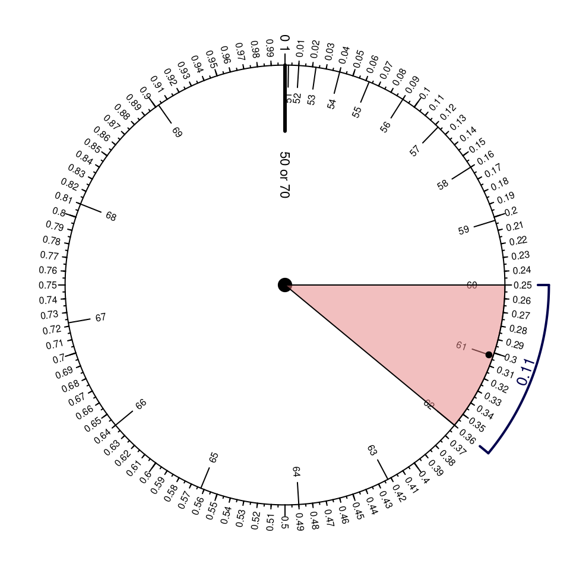

  You need to read coordinates to use the cumulative curve. The lower bound is at $x=60$, which corresponds to a cumulative proportion of 0.25. The upper bound is at $x=62$, which corresponds to a cumulative proportion of 0.36.
  $$0.36-0.25=0.11$$

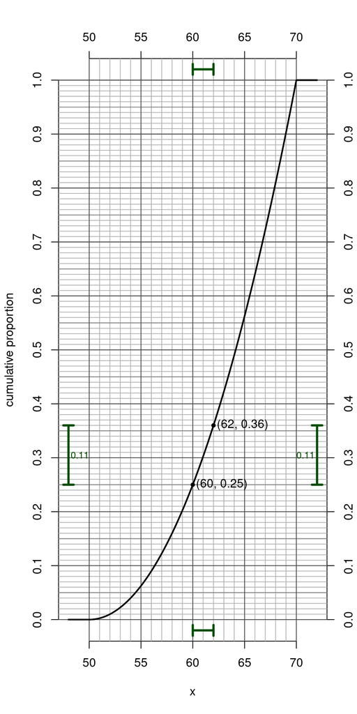

# Meta-information

extype: cloze exclozetype: num|num|num|num|num|num exsolution: 0.04|0.36|0.33|68|52|1 exname: estimate_area extol: 0.01|0.01|0.01|0.5|0.5|0.5 exextra[numwidth,character]: 999.99